# 6b Lab

Alyssa

2021-03-03

Week 6b: Lab  
Intro to RMarkdown 2

**Using any data we have used in class:**

- Put in this weeks data folder
- Create at least one table and one figure in an Rmarkdown file.
- Create the most beautiful RMarkdown output you can during lab hours in either an html, github doc, or pdf format.
- Make sure you have headings with clear explanations of what you are doing.
- Practice using markdown formatting with bold, italics, and lists.
- Make sure your outputs and scripts are saved in the appropriate folders.
- Keep proper coding etiquette (figures need to be pub quality as usual).

# Libraries

```r
library(palmerpenguins)
library(tidyverse)
library(here)
library(kableExtra)
library(rmdformats)
```

# Data

I have chosen to use the palmerpenguins data. I have made a long format of the data set as well as matching set of means. The means are taken of all variables by year, island, species, and sex.

```r
penguins <- glimpse(penguins)
```

```
## Rows: 344
## Columns: 8
## $ species           <fct> Adelie, Adelie, Adelie, Adelie, Adelie, Adelie, Adel…
## $ island            <fct> Torgersen, Torgersen, Torgersen, Torgersen, Torgerse…
## $ bill_length_mm    <dbl> 39.1, 39.5, 40.3, NA, 36.7, 39.3, 38.9, 39.2, 34.1, …
## $ bill_depth_mm     <dbl> 18.7, 17.4, 18.0, NA, 19.3, 20.6, 17.8, 19.6, 18.1, …
## $ flipper_length_mm <int> 181, 186, 195, NA, 193, 190, 181, 195, 193, 190, 186…
## $ body_mass_g       <int> 3750, 3800, 3250, NA, 3450, 3650, 3625, 4675, 3475, …
## $ sex               <fct> male, female, female, NA, female, male, female, male…
## $ year              <int> 2007, 2007, 2007, 2007, 2007, 2007, 2007, 2007, 2007…
```

```r
penguins <- penguins %>% relocate(year, island, species, sex) %>% filter(sex != "NA")

penguins_long <- penguins %>%
  pivot_longer(cols = c(5:8),
               names_to="variables",
               values_to="values")

means <- penguins %>%
  pivot_longer(cols = c(5:8),
               names_to="variables",
               values_to="values") %>%
  group_by(year, island, species, sex, variables) %>%
  summarise(means=mean(values, na.rm=T))

means_wide <- means %>% pivot_wider(id_cols = c(1:4),
                                     names_from="variables",
                                     values_from="means")
```

# Table

This table shows the mean body mass (g) of all the penguins grouped by species, island, and sex.

```r
penguins %>%
  group_by(species, island, sex) %>%
  summarise(mean = mean(body_mass_g, na.rm = TRUE)) %>%
  filter(sex != "NA") %>%
  pivot_wider(id_cols=c(1:2),
              names_from="sex",
              values_from="mean") %>%
  rename("Species" = "species",
         "Island" = "island",
         "Female" = "female",
         "Male" = "male") %>%
  kbl(caption = "<b>Penguins Mean Body Mass (g)</b>") %>%
  kable_classic() %>%
  kable_styling(bootstrap_options = c("hover", "condensed"), full_width = F) %>%
  collapse_rows(columns = 1, valign = "top") %>%
  row_spec(row=0, bold = T, background = "aliceblue")
```

**Penguins Mean Body Mass (g)**

| Species | Island | Female | Male |
| --- | --- | --- | --- |
| Adelie | Biscoe | 3369.318 | 4050.000 |
|  | Dream | 3344.444 | 4045.536 |
|  | Torgersen | 3395.833 | 4034.783 |
| Chinstrap | Dream | 3527.206 | 3938.971 |
| Gentoo | Biscoe | 4679.741 | 5484.836 |

# Plot

Plot all variables and their means for each year. The means are shown with the darker markers.

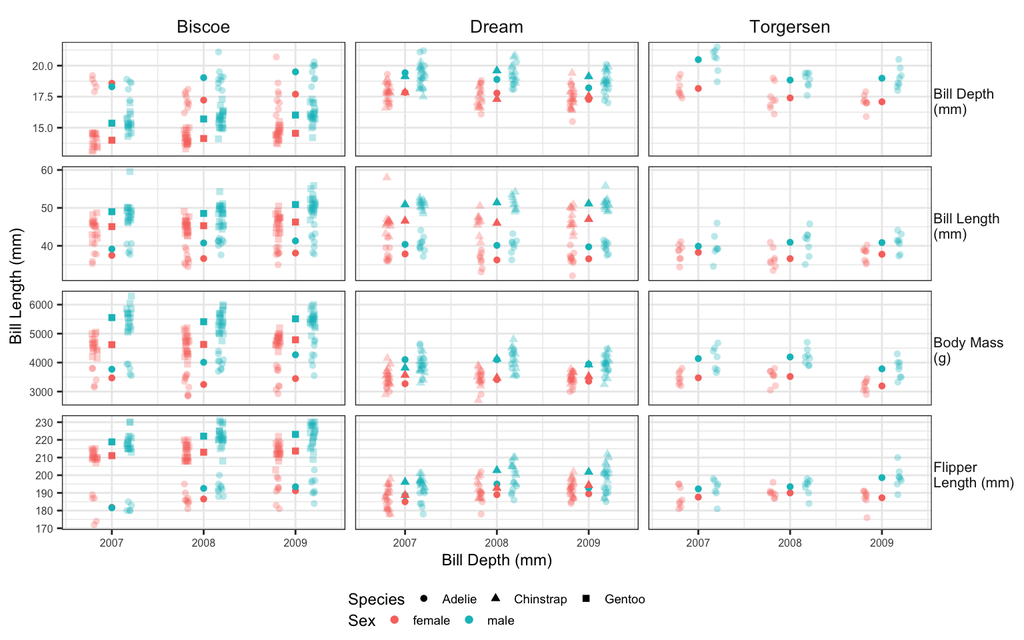

```r
penguins_long$variables <- factor(penguins_long$variables,
                                  levels = c("bill_depth_mm", "bill_length_mm",
                                             "body_mass_g", "flipper_length_mm"),
                                  labels = c("Bill Depth (mm)", "Bill Length (mm)",
                                             "Body Mass (g)", "Flipper Length (mm)"))
means$variables <- factor(means$variables,
                                  levels = c("bill_depth_mm", "bill_length_mm",
                                             "body_mass_g", "flipper_length_mm"),
                                  labels = c("Bill Depth (mm)", "Bill Length (mm)",
                                             "Body Mass (g)", "Flipper Length (mm)"))

penguins_long %>%
  ggplot(aes(x=year, y=values, color=sex, group=sex, shape=factor(species))) +
  geom_jitter(alpha=0.3, position = position_jitterdodge(0.2)) +
  geom_point(data=means, aes(x=year, y=means, shape=factor(species))) +
  facet_grid(variables~island, scale="free_y",
             labeller = label_wrap_gen(multi_line = TRUE, width = 12)) +
  theme_bw() +
  theme(legend.position = "bottom", legend.direction = "horizontal",
        legend.box = "vertical", legend.box.just = "left", legend.margin = margin(0),
        legend.key.size = unit(12, "points"), legend.text = element_text(size=7),
        legend.title = element_text(size=9), legend.spacing.y = unit(0, "lines"),
        strip.background = element_rect(fill = "white", color = "white"),
        strip.text = element_text(size=10),
        strip.text.y = element_text(angle = 0, size=8, hjust = 0,
                                         margin = margin(2, 0, 0, 1,
                                                unit = "pt")),
        axis.title = element_text(size=9), axis.text = element_text(size=6)) +
  labs(x = "Bill Depth (mm)", y = "Bill Length (mm)", color="Sex", shape="Species") +
  scale_x_continuous(breaks = seq(from=2007, to=2009, by=1))
```

## Bill Depth v Bill Length

plot of the bill length by the depth. the means are included and shown by the darker markers and labeled with their year.

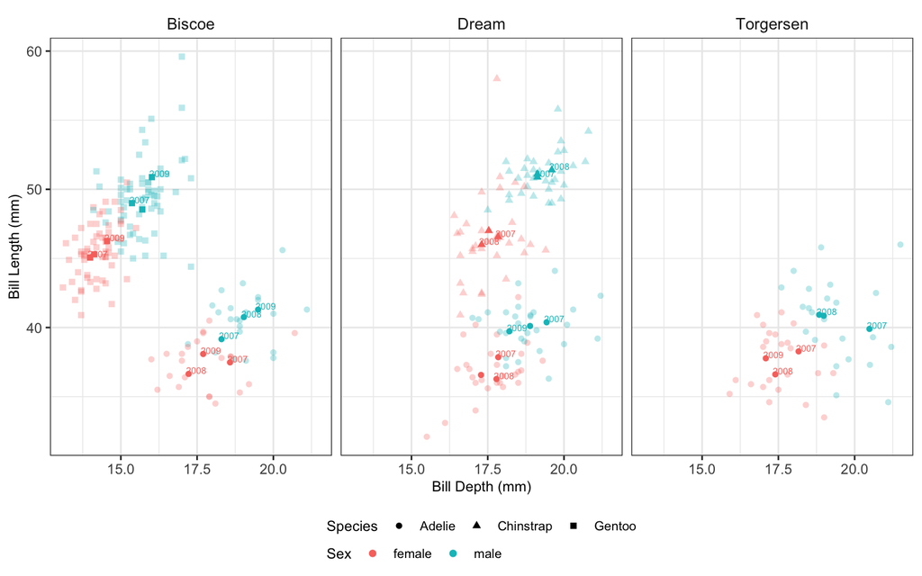

```r
penguins %>% filter(sex != "NA") %>%
  ggplot(aes(x=bill_depth_mm, y=bill_length_mm, color=sex, shape=factor(species))) +
  geom_point(alpha=0.3) +
  geom_point(data=means_wide, alpha=1) +
  geom_text(data=means_wide, aes(label=year), size=2, nudge_x = 0.25, nudge_y = 0.25,
            check_overlap = T) +
  facet_wrap(island~.) +
  theme_bw() +
  theme(legend.position = "bottom", legend.direction = "horizontal",
        legend.box = "vertical", legend.box.just = "left",
        legend.text = element_text(size=8), legend.title = element_text(size=9),
        legend.margin = margin(0), legend.spacing.y = unit(0, "lines"),
        strip.background = element_rect(fill = "white", color = "white"),
        strip.text = element_text(size=10), axis.title = element_text(size=9)) +
  labs(x = "Bill Depth (mm)", y = "Bill Length (mm)", color="Sex", shape="Species") +
  ggsave(here("Week_6", "Outputs", "Bill_Depth_Length.png"))
```

## flipper length v. body mass

plot of the body mass by the flipper length. the means are included and shown by the darker markers and labeled with their year.

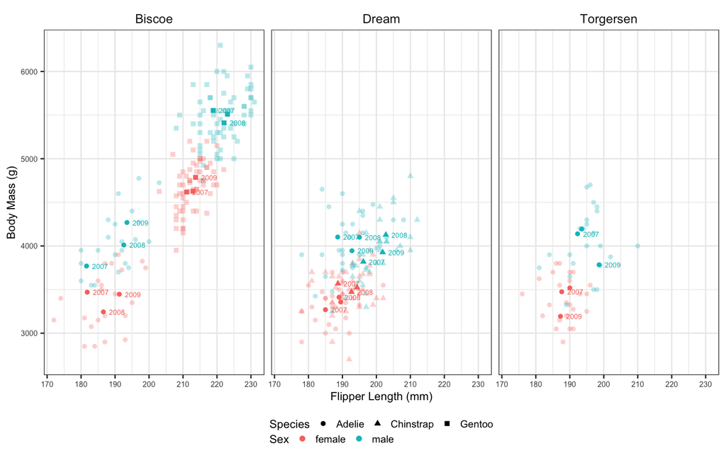

```r
penguins %>% filter(sex != "NA") %>%
  ggplot(aes(x=flipper_length_mm, y=body_mass_g, color=sex, shape=factor(species))) +
  geom_point(alpha=0.3) +
  geom_point(data=means_wide, alpha=1) +
  geom_text(data=means_wide, aes(label=year), size=2, nudge_x = 4, nudge_y = -0.7,
            check_overlap = T) +
  facet_wrap(island~.) +
  theme_bw() +
  theme(legend.position = "bottom", legend.direction = "horizontal",
        legend.box = "vertical", legend.box.just = "left",
        legend.box.margin = margin(0, 0, 0, 0), legend.key.size = unit(12, "points"),
        legend.text = element_text(size=8), legend.title = element_text(size=9),
        legend.margin = margin(0), legend.spacing.y = unit(0, "lines"),
        strip.background = element_rect(fill = "white", color = "white"),
        strip.text = element_text(size=10), axis.title = element_text(size=9),
        axis.text = element_text(size=6)) +
  labs(x = "Flipper Length (mm)", y = "Body Mass (g)", color="Sex", shape="Species")
```